# Music EDX Capstone Project Report

MM

27/02/2022

## INTRODUCTION

This is a report for the capstone project required to obtain the Data Science Professional Certification issued by Harvard University, via EDX platform.

Measurement of a song’s success is a relative matter. It could be assessed based on volume of sales, how popular it might be or from a purely artistic point of view regarding its aesthetics and characteristics.

For this project, I have defined as a measure of song success: whether a song was listed in the Billboard Hot 100 chart, and therefore classified as a “hit”.

I obtained and combined relevant data to predict whether a song can become a “hit” based on its audio features.

This analysis does not account for other possible confounding factors, such as marketing, performer abilities and trajectory, social or geographical environment, among others factors that could have a direct influence on a song becoming a hit.

This project was of particular interest to me. Among my hobbies, I like to compose, record music and play various instruments. This analysis helped me understanding better the characteristics of successful songs.

### Libraries

The following libraries are required for proper execution of the related R script file:

```r
library(tidyverse)
library(stringr)
library(spotifyr)
library(purrr)
library(skimr)
library(caret)
library(DataExplorer)
library(corrplot)
library(hrbrthemes)
library(factoextra)
library(Boruta)
library(rpart)
library(rpart.plot)
library(packcircles)
library(viridis)
library(caretEnsemble)
```

### Data Wrangling

I performed data wrangling operations to combine these datasets as follows:

The following code was used to perform the above mentioned data loading and wrangling operations:

```r
#####DATA LOADING####
#loading the data
Hot_100_Audio_Features <- read.csv("~/Hot 100 Audio Features.csv")
genres_v2 <- read.csv("~/genres_v2.csv")

##view the columns available
names(Hot_100_Audio_Features)
names(genres_v2)

##checking which columns are not in both datasets

setdiff(colnames(Hot_100_Audio_Features), colnames(genres_v2))

setdiff( colnames(genres_v2),colnames(Hot_100_Audio_Features))

##checking unique records per dataset

length(unique(Hot_100_Audio_Features$spotify_track_id))
length(unique(genres_v2$id))

##checking column classes
a<- lapply(Hot_100_Audio_Features, class)
b<-lapply(genres_v2, class)
str(Hot_100_Audio_Features)

#exploring NA's
Hot_100_Audio_Features %>% filter(is.na(SongID)== TRUE) %>% count()
Hot_100_Audio_Features %>% filter(is.na(Song)== TRUE) %>% count()
Hot_100_Audio_Features %>% filter(is.na(spotify_track_id)== TRUE) %>% count()
Hot_100_Audio_Features[(Hot_100_Audio_Features$Song==""),] %>% count()
Hot_100_Audio_Features[(Hot_100_Audio_Features$spotify_genre==""),]  %>% count()
Hot_100_Audio_Features[(is.na(Hot_100_Audio_Features$spotify_genre)== TRUE),]  %>% count()
Hot_100_Audio_Features[(Hot_100_Audio_Features$spotify_genre == "[]"),]  %>% count()

genres_v2 %>% filter(is.na(id ==TRUE)) %>% count()
genres_v2 %>% filter(is.na(song_name ==TRUE)) %>% count()
genres_v2[(genres_v2$song_name==""),]  %>% count()
genres_v2[(genres_v2$genre== "[]"),]  %>% count()

######DATA WRANGLING########
#removing rows in genres_v2 missing song name
genres_v2 <- genres_v2[!(genres_v2$song_name==""),]

#removing rows in Hot_100_Audio_Features  missing genre
Hot_100_Audio_Features <- Hot_100_Audio_Features[!(Hot_100_Audio_Features$spotify_genre==""),]
Hot_100_Audio_Features <- Hot_100_Audio_Features[(Hot_100_Audio_Features$spotify_genre != "[]"),]

#renaming columns
genres_v2 <- genres_v2 %>%   rename(., track_id = id )
Hot_100_Audio_Features <- Hot_100_Audio_Features %>%
  rename(., track_id = spotify_track_id, song_name = Song, genre = spotify_genre,
         duration_ms = spotify_track_duration_ms)

#defining class field
genres_v2$Is_hit <- 0 #means No hit
Hot_100_Audio_Features$Is_hit <- 1  # means Yes, it's a hit

#columns to drop
#Hot_100_Audio_Features:
exclude_Hot <- c("spotify_track_album", "SongID", "spotify_track_preview_url",
                 "spotify_track_explicit","spotify_track_popularity")

#genres_v2
exclude_genr <- c("type","uri","track_href", "analysis_url", "Unnamed..0" , "title")

#defining columns wanted in specific order

valid_fields <- c("track_id", "song_name", "Is_hit", "genre", "key", "mode", "tempo",
"danceability", "energy", "loudness", "speechiness", "acousticness",
"instrumentalness", "liveness", "valence","duration_ms",  "time_signature", "Performer")

#identifying the songs from genres_v2 that are not in Hot_100 (i.e. true no hits)

genres_v2_no_hits <- subset(genres_v2 ,!(track_id%in%Hot_100_Audio_Features$track_id))

####OBTAINING SAMPLE OF PERFORMERS NAMES OF NON-HIT SONGS FOR CONTEXT###

#creating authentication
Sys.setenv(SPOTIFY_CLIENT_ID = Client_Id)  # client id not shared here for security
Sys.setenv(SPOTIFY_CLIENT_SECRET = Client_secret) #client secret not shared here for security

#defining a function to obtain artists names
spotify_filter_artist_id_func <- function(x) {
  c<- get_track(x, market = NULL, authorization = get_spotify_access_token())
  d<- c$artists$id
  e<- get_artists(d, authorization = get_spotify_access_token())
  f<- e$name
  g<-data.frame(song_id= x, artist_id = d, artist_name = f)
  return(g)
}

#getting samples (limited to 50 songs per run)

spotify_filter_artist_id <- lapply( sample(genres_v2_no_hits$track_id,50), spotify_filter_artist_id_func)

spotify_filter_artist_id <-  bind_rows(spotify_filter_artist_id, .id = "column_label")

spotify_filter_artist_id2 <- lapply( sample(genres_v2_no_hits$track_id,50), spotify_filter_artist_id_func)

spotify_filter_artist_id2 <-  bind_rows(spotify_filter_artist_id, .id = "column_label")


spotify_filter_artist_id3 <- lapply( sample(genres_v2_no_hits$track_id,50), spotify_filter_artist_id_func)

spotify_filter_artist_id3 <-  bind_rows(spotify_filter_artist_id, .id = "column_label")

#merging samples
no_hits_performers_sample <- rbind(spotify_filter_artist_id, spotify_filter_artist_id2, spotify_filter_artist_id3)

###################################################################

#creating "Performers" column in genres_v2_no_hits

genres_v2_no_hits <- merge(genres_v2_no_hits, no_hits_performers_sample[ , c("song_id", "artist_name")], by.x = "track_id", by.y =  "song_id", all.x = TRUE)

genres_v2_no_hits <- genres_v2_no_hits %>% rename(., Performer = artist_name)

#keeping only unique tracks

genres_v2_no_hits<- genres_v2_no_hits %>% distinct(track_id, .keep_all = TRUE)

Hot_100_Audio_Features_uniques <- Hot_100_Audio_Features %>% distinct(track_id, .keep_all = TRUE)

#checking datasets completeness

genres_v2_no_hits[(genres_v2_no_hits$track_id==""),] %>% count()
genres_v2_no_hits %>% filter(is.na(genre)== TRUE) %>% count()
genres_v2_no_hits  %>% filter(genre == "") %>% count()

Hot_100_Audio_Features_uniques[(Hot_100_Audio_Features_uniques$track_id==""),] %>% count()

Hot_100_Audio_Features_uniques %>% filter(is.na(track_id)== TRUE) %>% count()

Hot_100_Audio_Features_uniques %>% filter(is.na(danceability)== TRUE) %>% count()

Hot_100_Audio_Features_uniques %>% filter(is.na(genre)== TRUE) %>% count()

Hot_100_Audio_Features_uniques  %>% filter(genre == "") %>% count()

Hot_100_Audio_Features_uniques  %>% filter(genre == "[]") %>% count()

#excluding rows with no features from hot_100 data

Hot_100_Audio_Features_uniques<- Hot_100_Audio_Features_uniques %>% filter(!is.na(danceability)== TRUE)

#COMBINING DATASETS and keeping balanced classes (at 16656 each)

#combining datasets
Dataset <- rbind(genres_v2_no_hits %>% select(all_of(valid_fields)),Hot_100_Audio_Features_uniques[1:16656,] %>% select(all_of(valid_fields)))

#cleansing genre variable in Dataset to eliminate special characters and also only take the first genre associated to the song

Dataset$genre_clean  <- Dataset$genre  %>%   ifelse(str_detect(., ",", negate = FALSE),  str_extract(.,"^(.+?),") %>% str_replace_all(., "[:punct:]", " ") %>% trimws(.),.) %>%
  str_replace_all(., "[:punct:]", " ") %>% trimws(.)


#dataset profiling
summary(Dataset)

Dataset_skim_summary <- Dataset  %>% skim()

#checking completeness of final dataset
Dataset[(Dataset$key==""),] %>% count()

Dataset %>% filter(is.na(track_id)== TRUE) %>% count()

Dataset %>% filter(genre == "[]") %>% count()

Dataset %>% filter(genre == "") %>% count()

#ensuring classes remain balanced
Dataset %>% group_by(Is_hit) %>% summarise(n = n())

#counting songs per genre
dataset_genre <- Dataset %>% select(genre,genre_clean) %>%   group_by(genre_clean, genre) %>% summarise(n = n())

#deleting tables not longer needed to liberate memory:
rm(list=c("genres_v2", "genres_v2_no_hits", "Hot_100_Audio_Features","Hot_100_Audio_Features_uniques",
          "spotify_filter_artist_id", "spotify_filter_artist_id2", "spotify_filter_artist_id3",
          "a", "b", "valid_fields","exclude_genr", "exclude_Hot", "Dataset_skim_summary"))

######DATA SPLITTING FOR MODELLING#####

# Split-out validation dataset

set.seed(75, sample.kind="Rounding")

# create a list of 80% of the rows in the cleansed Dataset  for training
validationIndex <- createDataPartition(y = Dataset$Is_hit , times = 1, p=0.80, list=FALSE)
# select 20% of the data for validation
validation <- Dataset[-validationIndex,]
# use the remaining 80% of data to training the models
training <- Dataset[validationIndex,]
```

This new “Dataset” was then used to create a training partition (80%) and validation partition (20%).

I made a choice to maintain classes balanced to avoid any undue influence from this element. However, this might distant from the actual population of songs across the world (where there is a lower proportion of hit songs than non-hit songs). This has been considered in the conclusions of this report.

Further review and analysis was undertaken as explained in the following sections and I documented the project through the following files for submission to EDX:

- An Rmd file report detailing the methodology applied,
- A PDF report (issued from the Rmd file above mentioned), and
- An R script file that generates the analysis and predictions

## About the source datasets

### Hot 100 Billboard songs

The Billboard Hot 100 is the music industry standard record chart in the United States for songs, published weekly by Billboard magazine. Chart rankings are based on sales, radio play, and online streaming in the United States.

Every week, Billboard releases “The Hot 100” chart of songs that were trending on sales and airplay for that week. This dataset is a collection of all “The Hot 100” charts released since its inception in 1958. The dataset includes audio features for the songs taken from the Spotify database. The dataset is hosted in data.world website.

### Dataset of songs in Spotify

This is a data set containing several songs by genres and provides the related Spotify audio features. It is hosted in Kaggel. It was created in December 2020.

## About the combined dataset

The following fields were included in the final Dataset before partitioning the data into training and validation sets:

```r
sapply(Dataset, class) %>% as.data.frame(.)
```

```
##                          .
## track_id         character
## song_name        character
## Is_hit             numeric
## genre            character
## key                integer
## mode               integer
## tempo              numeric
## danceability       numeric
## energy             numeric
## loudness           numeric
## speechiness        numeric
## acousticness       numeric
## instrumentalness   numeric
## liveness           numeric
## valence            numeric
## duration_ms        integer
## time_signature     integer
## Performer        character
## genre_clean      character
```

- **track_id**: the Spotify ID for the track
- **song_name**: title of the song
- **Is_hit**: binary variable stating 0 if the song was not within the top 100 billboard chart or 1 if it was included (labels “No”, “Yes”)
- **genre**: identify the song style or musical tendency
- **key**: The key the track is in. Integers map to pitches using standard pitch class notation. E.g. 0 = C, 1 = C♯/D♭, 2 = D, and so on. If no key was detected, the value is -1.
- **mode**: Mode indicates the modality (major or minor) of a track, the type of scale from which its melodic content is derived. Major is represented by 1 and minor is 0.
- **tempo**: The overall estimated tempo of a track in beats per minute (BPM). In musical terminology, tempo is the speed or pace of a given piece and derives directly from the average beat duration.
- **danceability**: Danceability describes how suitable a track is for dancing based on a combination of musical elements including tempo, rhythm stability, beat strength, and overall regularity. A value of 0.0 is least danceable and 1.0 is most danceable.
- **energy**: Energy is a measure from 0.0 to 1.0 and represents a perceptual measure of intensity and activity. Typically, energetic tracks feel fast, loud, and noisy. For example, death metal has high energy, while a Bach prelude scores low on the scale. Perceptual features contributing to this attribute include dynamic range, perceived loudness, timbre, onset rate, and general entropy.
- **loudness**: The overall loudness of a track in decibels (dB). Loudness values are averaged across the entire track and are useful for comparing relative loudness of tracks. Loudness is the quality of a sound that is the primary psychological correlate of physical strength (amplitude). Values typically range between -60 and 0 db.
- **speechiness**: Speechiness detects the presence of spoken words in a track. The more exclusively speech-like the recording (e.g. talk show, audio book, poetry), the closer to 1.0 the attribute value. Values above 0.66 describe tracks that are probably made entirely of spoken words. Values between 0.33 and 0.66 describe tracks that may contain both music and speech, either in sections or layered, including such cases as rap music. Values below 0.33 most likely represent music and other non-speech-like tracks.
- **acousticness**: A confidence measure from 0.0 to 1.0 of whether the track is acoustic. 1.0 represents high confidence the track is acoustic.
- **instrumentalness**: Predicts whether a track contains no vocals. “Ooh” and “aah” sounds are treated as instrumental in this context. Rap or spoken word tracks are clearly “vocal”. The closer the instrumentalness value is to 1.0, the greater likelihood the track contains no vocal content. Values above 0.5 are intended to represent instrumental tracks, but confidence is higher as the value approaches 1.0.
- **liveness**: Detects the presence of an audience in the recording. Higher liveness values represent an increased probability that the track was performed live. A value above 0.8 provides strong likelihood that the track is live.
- **valence**: a measure from 0.0 to 1.0 describing the musical positiveness conveyed by a track. Tracks with high valence sound more positive (e.g. happy, cheerful, euphoric), while tracks with low valence sound more negative (e.g. sad, depressed, angry).
- **duration_ms**: The duration of the track in milliseconds.
- **time_signature**: An estimated time signature. The time signature (meter) is a notational convention to specify how many beats are in each bar (or measure). The time signature have the following values: 1, 3, 4, 5 representing the beats on a bar for the time signature (1/4, 3/4, 4/4, 5/4). Items with value zero represents that data was missing. For example category “4/4” should be read as “4 by 4”.
- **Performer**: name of the artist that perform the song. This data is missing for the majority of non-hit songs due to data limitations.
- **genre_clean**: this is the genre field without special characters and only the first genre for those songs that had more than one.

The consolidated Dataset contained 33,312 records and 19 variables. The following is a detail of top 10 performers by hit and non-hit songs for context:

```r
#checking performers' names for hit & non-hit songs in consolidated Dataset (before partition)
#hit songs
Dataset %>% filter(Is_hit== "1") %>% group_by(Performer,Is_hit) %>%
  summarise(number_songs = n()) %>% arrange(desc(number_songs)) %>% head(10)
```

```
## # A tibble: 10 x 3
## # Groups:   Performer [10]
##    Performer          Is_hit number_songs
##    <chr>               <dbl>        <int>
##  1 Glee Cast               1          131
##  2 Taylor Swift            1           83
##  3 Drake                   1           70
##  4 The Beatles             1           46
##  5 Madonna                 1           43
##  6 The Rolling Stones      1           43
##  7 Elton John              1           41
##  8 Stevie Wonder           1           40
##  9 Justin Bieber           1           39
## 10 Aretha Franklin         1           38
```

```r
#non-hit songs
Dataset %>% filter(Is_hit== "0" & !is.na(Performer)) %>% group_by(Performer,Is_hit) %>%
  summarise(number_songs = n()) %>% arrange(desc(number_songs)) %>% head(10)
```

```
## # A tibble: 10 x 3
## # Groups:   Performer [10]
##    Performer       Is_hit number_songs
##    <chr>            <dbl>        <int>
##  1 Aroc!                0            1
##  2 CHVRN                0            1
##  3 DaBaby               0            1
##  4 Elestu               0            1
##  5 Eric Bellinger       0            1
##  6 Freddie Dredd        0            1
##  7 Fukkit               0            1
##  8 Ghostface Playa      0            1
##  9 gizmo                0            1
## 10 Great Dane           0            1
```

```r
#checking Michael Jackson songs
Dataset %>% filter(Performer == "Michael Jackson") %>% group_by(Performer,Is_hit) %>%
  summarise(number_songs = n())
```

```
## # A tibble: 1 x 3
## # Groups:   Performer [1]
##   Performer       Is_hit number_songs
##   <chr>            <dbl>        <int>
## 1 Michael Jackson      1           27
```

To illustrate the nature of the dataset, I also ran a check for Michael Jackson as he was one of the most popular performers of all time. We can see that for hit songs most performer names are familiar, while this is not the case for non-hit songs.

## About the training dataset

The training dataset contained 26,650 observations and originally 19 columns, later two more columns were created. The following details were noted:

- There were 14 continue and 7 categorical variables in the training dataset (This is the same for the validation set).
- Only 50% of the rows were fully completed, which indicate the presence of NA values in the dataset. Most NA’s related to field: “Performer”.

```r
# dimensions of dataset
dim(training)

#exploring training data
training %>% introduce()
```

[figure not shown]

```r
#exploring training data
training %>% plot_intro()
```

```r
#checking for missing values

training %>% profile_missing()  # data frame of the missing values % per variable
```

```
##                feature num_missing pct_missing
## 1             track_id           0   0.0000000
## 2            song_name           0   0.0000000
## 3               Is_hit           0   0.0000000
## 4                genre           0   0.0000000
## 5                  key           0   0.0000000
## 6                 mode           0   0.0000000
## 7                tempo           0   0.0000000
## 8         danceability           0   0.0000000
## 9               energy           0   0.0000000
## 10            loudness           0   0.0000000
## 11         speechiness           0   0.0000000
## 12        acousticness           0   0.0000000
## 13    instrumentalness           0   0.0000000
## 14            liveness           0   0.0000000
## 15             valence           0   0.0000000
## 16         duration_ms           0   0.0000000
## 17      time_signature           0   0.0000000
## 18           Performer       13312   0.4995122
## 19         genre_clean           0   0.0000000
## 20 genre_clean_factors           0   0.0000000
## 21           new_genre           0   0.0000000
```

The following indicates the variables classes and provides an overview of the training dataset first 3 rows:

```r
## variables types
sapply(training, class) %>% as.data.frame(.)
```

```
##                             .
## track_id            character
## song_name           character
## Is_hit                 factor
## genre               character
## key                   numeric
## mode                  numeric
## tempo                 numeric
## danceability          numeric
## energy                numeric
## loudness              numeric
## speechiness           numeric
## acousticness          numeric
## instrumentalness      numeric
## liveness              numeric
## valence               numeric
## duration_ms           numeric
## time_signature        integer
## Performer           character
## genre_clean         character
## genre_clean_factors    factor
## new_genre             numeric
```

```r
## reviewing the first 5 rows
head(training, n=3)
```

```
##                 track_id                            song_name Is_hit     genre
## 1 003VDDA7J3Xb2ZFlNx7nIZ                              YELL OH     No       Rap
## 2 004Vn8Q2q19hVTAvcNrocD                              Eclipse     No Dark Trap
## 3 006hfStQk9L7MVT9RcDeva A Part Of Me (feat. Laura Whiteside)     No       Emo
##   key mode   tempo danceability energy loudness speechiness acousticness
## 1   6    0  74.496        0.842  0.578   -6.050      0.1380      0.00419
## 2   7    1 128.007        0.516  0.853   -8.572      0.0476      0.00131
## 3   4    1 200.036        0.372  0.875   -0.946      0.0435      0.37600
##   instrumentalness liveness valence duration_ms time_signature Performer
## 1         0.00e+00    0.228  0.1900      236779              4      <NA>
## 2         8.79e-01    0.669  0.0512      195000              4      <NA>
## 3         5.16e-05    0.103  0.3130      189415              4      <NA>
##   genre_clean genre_clean_factors new_genre
## 1         Rap                 Rap 0.8784861
## 2   Dark Trap           Dark Trap 0.4083665
## 3         Emo                 Emo 0.5298805
```

I had a first glance of the distributions for most variables. Inspected the variable “key” and noted that the dataset includes songs in all keys:

```r
# summary
summary(training)

#checking key field distribution
unique(training$key)
```

Finally, confirmed that the classes remained balanced after partition:

```r
#ensuring classes remained balanced after partition

# class distribution
cbind(freq=table(training$Is_hit), percentage=prop.table(table(training$Is_hit))*100)
```

```
##      freq percentage
## No  13325         50
## Yes 13325         50
```

## About the validation dataset

The validation dataset contained 6,662 observations and originally 19 columns. Later, two more columns were created.

We can see that the same columns are included in the validation dataset. The whole range of song keys are included and classes remained balanced after partition.

```r
# summary
str(validation)
```

```
## 'data.frame':    6662 obs. of  21 variables:
##  $ track_id           : chr  "00oy0A1Y3IS8SgP8W8xS30" "00rOE00OKN8IlG1MQvgHma" "00TxSiyaZAqr0xUpGEe55s" "01AJvnKOeHtFe9stZ7AGfm" ...
##  $ song_name          : chr  "Feeling Whitney" "We're Not the Same" "Tellin Ya (feat. Lil PJ)" "Hityawitdat" ...
##  $ Is_hit             : Factor w/ 2 levels "No","Yes": 1 1 1 1 1 1 1 1 1 1 ...
##  $ genre              : chr  "Hiphop" "Trap Metal" "Underground Rap" "Hiphop" ...
##  $ key                : num  0 8 1 11 7 4 8 1 10 8 ...
##  $ mode               : num  1 0 0 0 1 1 1 0 0 0 ...
##  $ tempo              : num  162 181 154 181 149 ...
##  $ danceability       : num  0.433 0.291 0.765 0.824 0.867 0.773 0.687 0.559 0.798 0.933 ...
##  $ energy             : num  0.223 0.954 0.422 0.817 0.403 0.489 0.653 0.963 0.553 0.878 ...
##  $ loudness           : num  -12.62 -4.19 -8.76 -5.93 -13.74 ...
##  $ speechiness        : num  0.0375 0.465 0.485 0.36 0.484 0.141 0.0696 0.0694 0.348 0.0791 ...
##  $ acousticness       : num  0.81 0.000131 0.104 0.169 0.099 0.117 0.0185 0.0372 0.102 0.0884 ...
##  $ instrumentalness   : num  3.67e-06 1.90e-02 0.00 0.00 9.30e-06 0.00 5.34e-01 4.73e-01 0.00 0.00 ...
##  $ liveness           : num  0.229 0.501 0.107 0.354 0.229 0.163 0.326 0.238 0.113 0.0833 ...
##  $ valence            : num  0.227 0.324 0.267 0.685 0.59 0.596 0.529 0.163 0.158 0.409 ...
##  $ duration_ms        : num  257267 170342 174545 193000 167706 ...
##  $ time_signature     : int  4 4 4 4 4 4 4 4 4 4 ...
##  $ Performer          : chr  NA NA NA NA ...
##  $ genre_clean        : chr  "Hiphop" "Trap Metal" "Underground Rap" "Hiphop" ...
##  $ genre_clean_factors: Factor w/ 312 levels "a cappella","acoustic pop",..: 199 305 310 199 310 199 131 131 284 305 ...
##  $ new_genre          : num  0.637 0.977 0.994 0.637 0.994 ...
```

```r
unique(validation$key)
```

```
##  [1]  0  8  1 11  7  4 10  9  6  2  5  3
```

```r
#ensuring classes remained balanced after partition

# class distribution
cbind(freq=table(validation$Is_hit), percentage=prop.table(table(validation$Is_hit))*100)
```

```
##     freq percentage
## No  3331         50
## Yes 3331         50
```

## Cleanising of certain variables

To aid with data visualisations and interpretation of the model, I relabeled the class variable “Is_hit” and converted the genres variable to factors using the following code:

```r
#modifying labels for ease of understanding

#on training dataset
levels(training$Is_hit) <- c("No","Yes")
head(training$Is_hit)

#on validation dataset
levels(validation$Is_hit) <- c("No","Yes")
head(validation$Is_hit)

#converting genres clean column to factors

training$genre_clean_factors <- as.factor(training$genre_clean)

#replicating it in validation dataset

validation$genre_clean_factors <- as.factor(validation$genre_clean)
```

## METHODOLOGY:

## Exploratory data analysis

### Initial assumptions and expectations

Before looking in detail at the data, I started my analysis by theorising the following ideas based on my musical knowledge and intuition.

I have separated these in assumptions subsequently supported and non-supported by data.

**Initial assumptions subsequently non-supported by data:**

- **energy**: It is possible that people would prefer more energetic songs than slow songs. Although some ballads are quite popular.
- **loudness**: this item should be associated with energy and may be also higher in songs that include more instruments or are recorded at higher volumes. My guess is that people would prefer songs that have a medium to high level of loudness. This probably needs to be considered based on population preference (partially supported by data)
- **duration_ms**: I believe songs that are too long or short will not be very popular (partially supported by data)
- **time signature**: most conventional time signature is 4/4. Therefore, most popular songs should be in this time signature (partially supported by data)
- **Other factors**: many other factors outside audio features have an impact, such as marketing, artist, etc. (No data available).

### Data Visualisations

I used the above to guide my exploratory data analysis and formulate research questions to identify features that could be good predictors:

**Correlations**

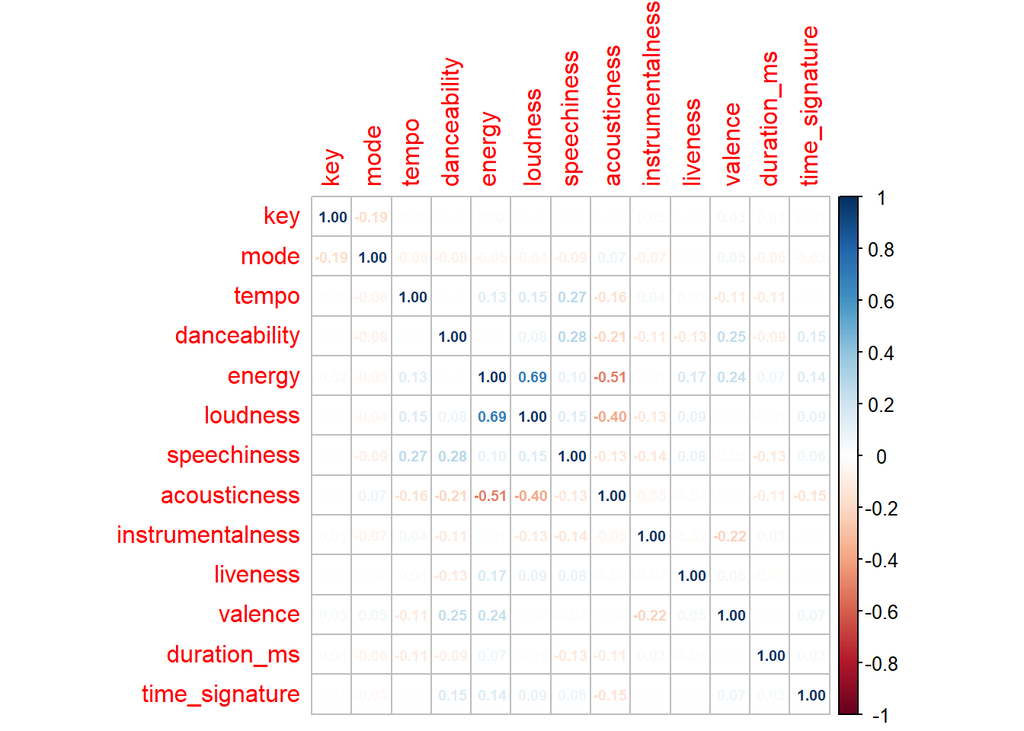

```r
# Data visualizations

# Creating index of predictors
features_index <- c(5:17,20)
features_index_num <- c(5:17)

#checking correlations
corr_training <-cor(training[features_index_num])

corrplot(corr_training, method="number",type= "full",insig = "blank", number.cex = 0.6)
```

**Correlations insights:**

- There is a positive correlation between energy & loudness (0.69). Therefore, energetic songs have a tendency to be louder. We could probably exclude one of these features.
- There is a negative correlation between energy/loudness and acousticness. Songs that are more energetic might have less acoustic instruments (probably the instrumentation includes electric/electronic music as well as computer generated effects)
- There are some other minor positive correlations, such as: ** valence slightly correlates to danceability, ** speechiness slightly correlates to danceability and tempo
- There are some minor negative correlations: ** danceability and acousticness (i.e there is a small tendency to use electric instruments in songs that are made for dancing), ** danceability and instrumentalness, ** valence and instrumentalness

**Distributions: histograms for each potential predictor**

The following code allows to have a quick glance at the distribution of the variables:

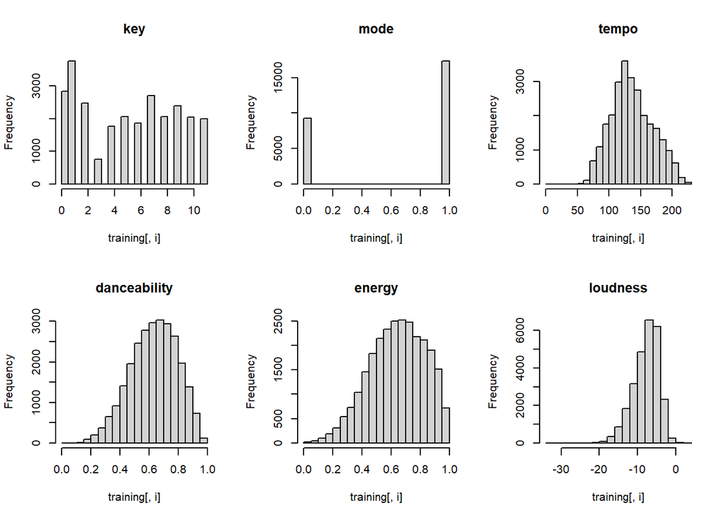

```r
# histograms each numeric predictor (separated in groups to ease visualization)
par(mfrow=c(2,3))
for(i in 5:10) {
  hist(training[,i], main=names(training)[i])
}
```

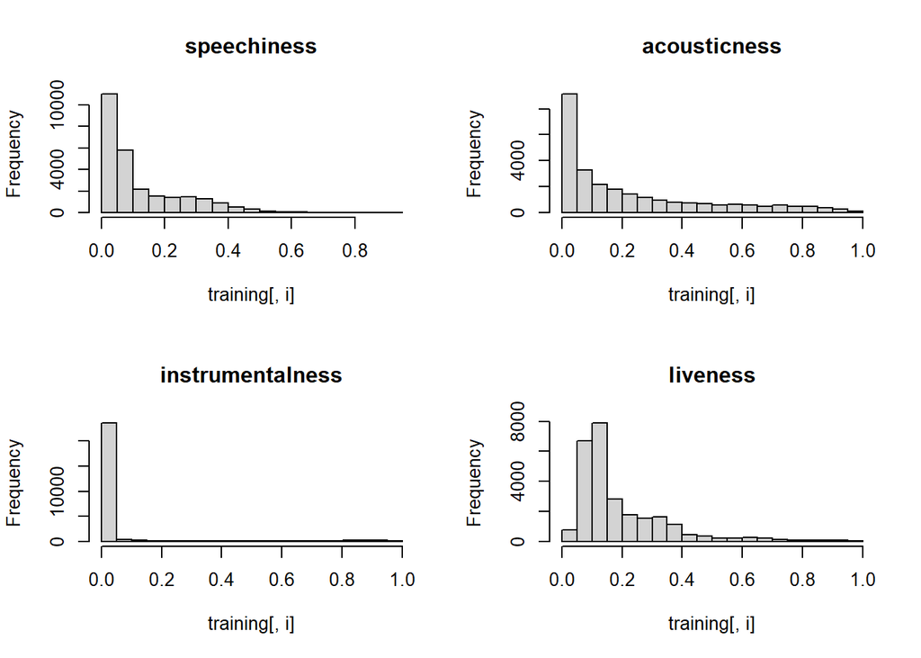

```r
par(mfrow=c(2,2))
for(i in 11:14) {
  hist(training[,i], main=names(training)[i])
}
```

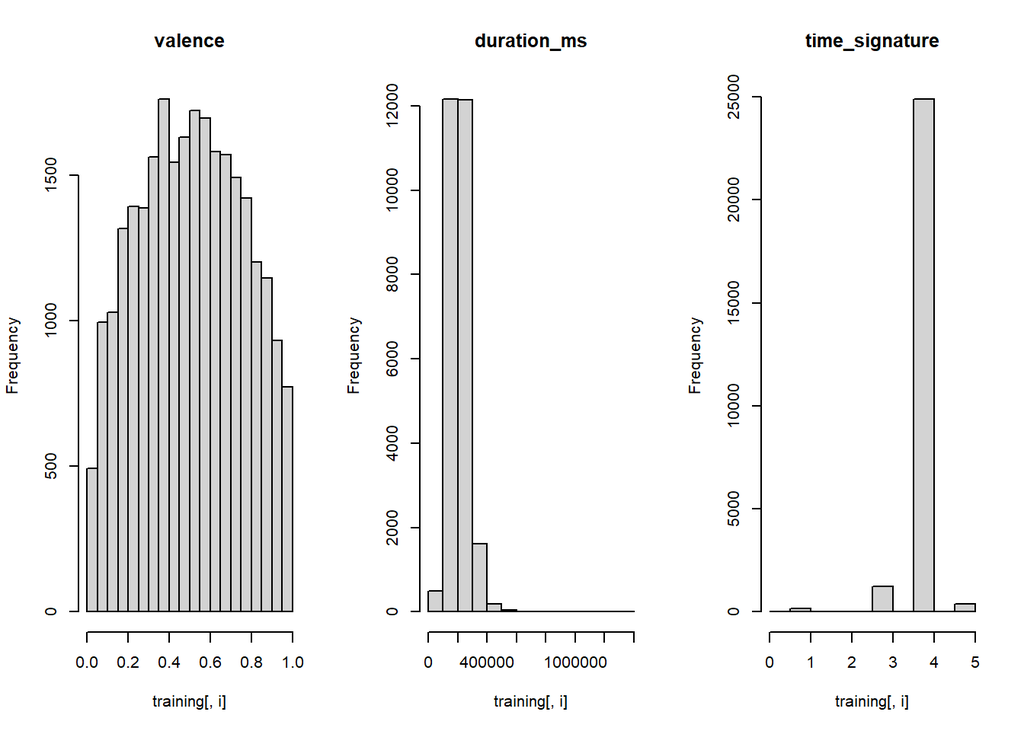

```r
par(mfrow=c(1,3))
for(i in 15:17) {
  hist(training[,i], main=names(training)[i])
}
```

**Distributions: box plots for each potential predictor**

I explored the distributions per classes for all potential predictors by using box plots:

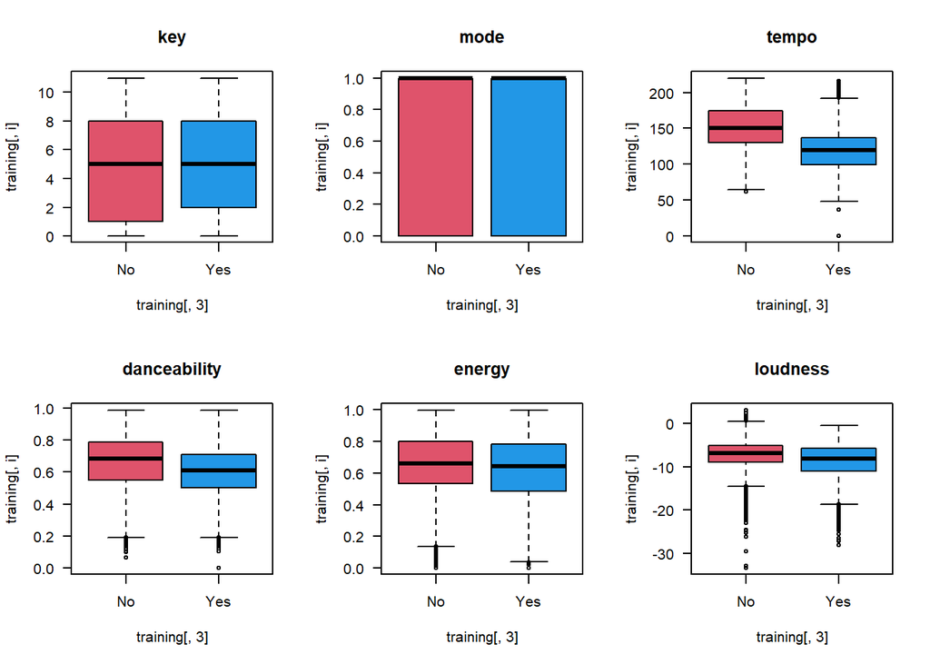

```r
par(mfrow=c(2,3))
for(i in 5:10) {
  boxplot(training[,i] ~ training[,3] , main=names(training)[i], las =1, col= c(2,4))

}
```

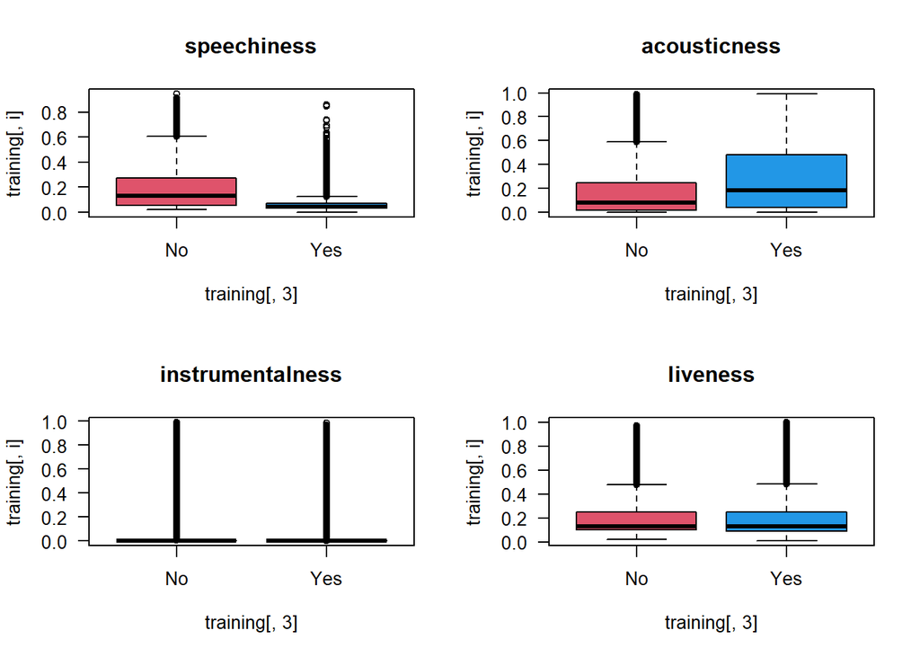

```r
par(mfrow=c(2,2))
for(i in 11:14) {
  boxplot(training[,i] ~ training[,3] , main=names(training)[i], las =1, col= c(2,4))

}
```

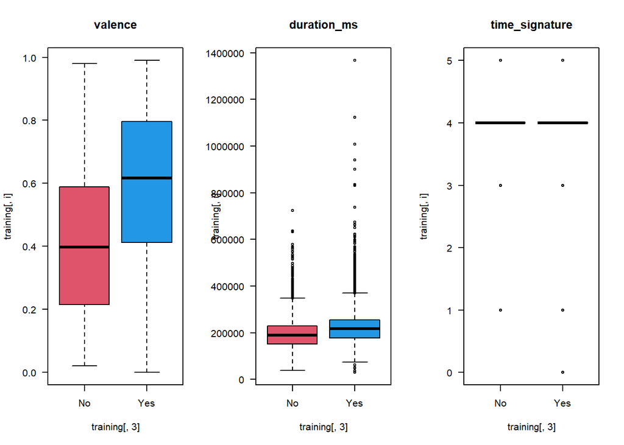

```r
par(mfrow=c(1,3))
for(i in 15:17) {
  boxplot(training[,i] ~ training[,3] , main=names(training)[i], las =1, col= c(2,4))

  }
```

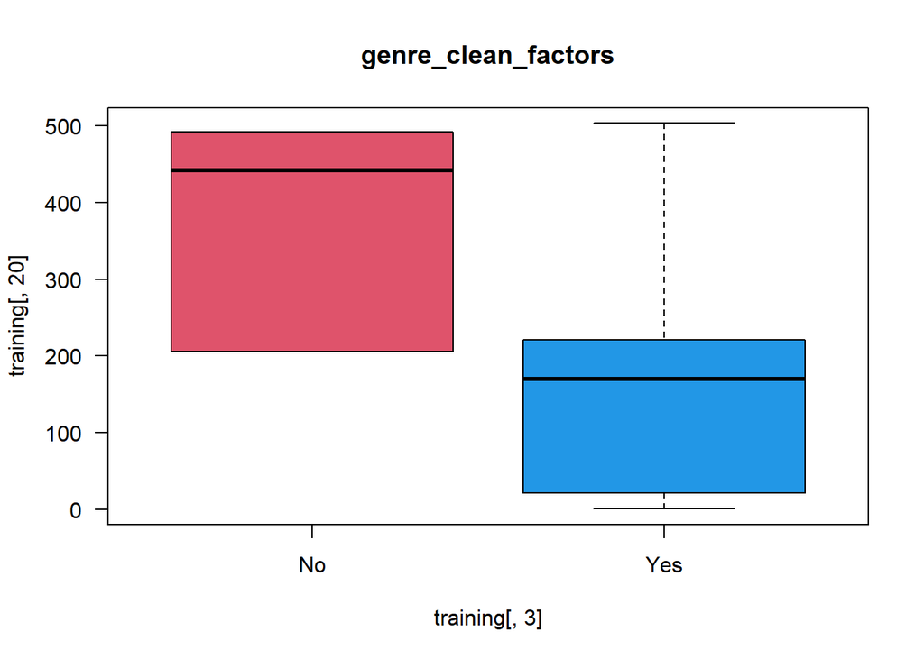

```r
par(mfrow=c(1,1))
boxplot(training[,20] ~ training[,3] , main=names(training)[20], las =1, col= c(2,4))
```

**Distributions insights:**

At first glance we can see a variety of distributions, with some variables presenting a normal distribution (tempo, danceability, energy, loudness and valence), while others are right skewed (speechiness, acousticness, instrumentalness and liveness). There are also a number of categorical variables.

When splitting the distribution by class, we can see that certain variables such as genres, valence and tempo have a clear distinction in the distribution between classes and might be good candidates for predictors.

### Research questions:

To deepen my understanding of the data I conducted further analysis to address research questions derived from the insights previously obtained.

I have divided this analysis in two groups:

- features describing songs types
- features describing elements of songs speed

**Analysis part I: features describing songs types**

**What are the most common keys by class?**

To answer this question i used the following code to determine the number of songs by key and by class:

```r
by_key_count <-training %>% select(key, Is_hit) %>% group_by( key, Is_hit) %>% summarise(total_songs = n())
```

and plotted the result as follows:

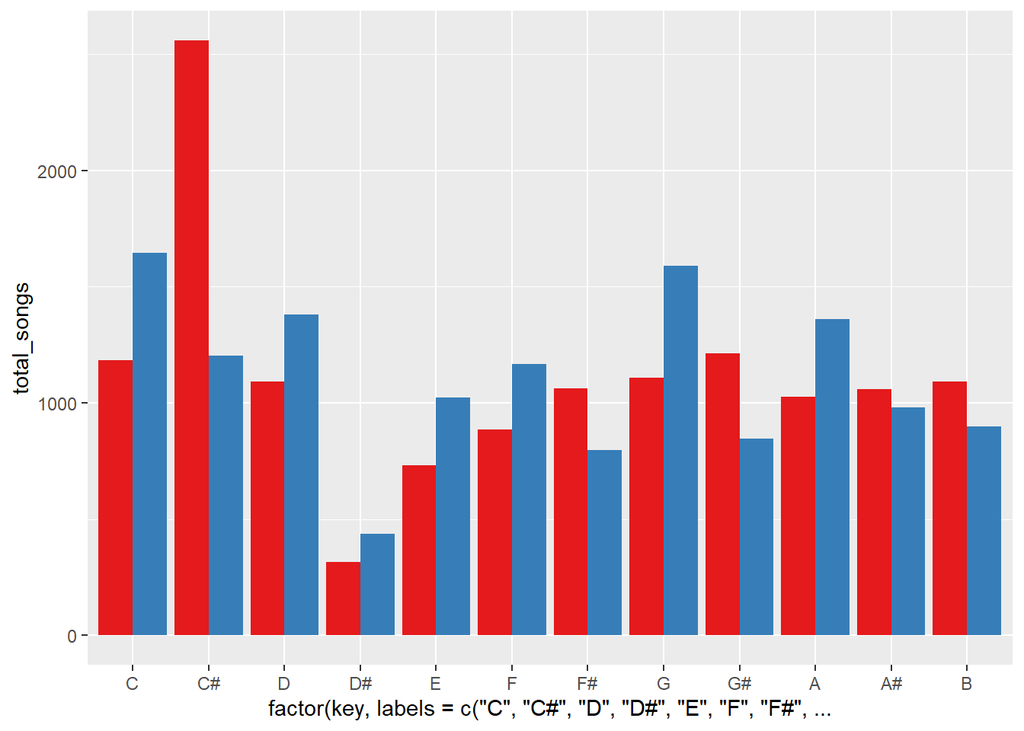

```r
 by_key_count %>% ggplot(., aes(x=factor(key, labels =c("C","C#","D","D#","E","F","F#","G","G#","A","A#","B")),
                                 y = total_songs, fill = Is_hit )) +
    geom_bar(stat = "Identity" , position = "dodge") +
    scale_fill_brewer(palette = "Set1")  +
    theme(legend.position="none")
```

**insights:**

- There are hit and non-hit songs across all tonalities (keys).
- Key analysis indicates that most common hit songs are in C (0) , G (7), D(2) and A(9) in that order. C# tonality is the key with most non-hit songs. The distribution of classes for each key might serve to calculate the probability of a song being a hit. Therefore, it might be a good candidate for predictor in logistic regression models.
- We can see that songs composed in D# scales are less frequent, and there is a tendency in this tonality to favor hit songs.

**what are the most common genres by class?**

The following code helped me answering the question:

```r
#counting the songs by genre and class
by_genre_count <-training %>% select(genre_clean_factors, Is_hit) %>% group_by( genre_clean_factors, Is_hit) %>% summarise(total_songs = n())

summary(by_genre_count$total_songs)

#I also considered the proportion of of hit non-hit by genre and the distribution
prop_bygenre <- prop.table(table(training[,c("genre_clean_factors", "Is_hit")]), margin = 2 ) *100

# distribution of  songs per genre
by_genre_count %>% group_by(total_songs) %>%
  summarise(freq= n())%>% ggplot(., aes(x=as.factor(total_songs), y = freq )) +
  geom_bar(stat = "Identity" ) +
  theme(legend.position="none") +
  theme(axis.text.x = element_text(angle = 90, vjust = 0.5, hjust=1))

#top ten genres for hit songs (by count of songs)
by_genre_count %>% filter(Is_hit == "1") %>%
    arrange(desc(total_songs)) %>%
    head(10)

#top ten genres for non-hit songs (by count of songs)
by_genre_count %>% filter(Is_hit == "0") %>%
    arrange(desc(total_songs)) %>%
    head(10)
```

**Insights:**

- Top ten genres for hit songs (by count of songs) are: 1 adult standards 2 album rock 3 dance pop 4 contemporary country 5 classic soul 6 brill building pop 7 alt hip hop 8 disco 9 alternative metal 10 pop
- There are only eight genres in the data for non-hit songs (by count of songs):

  1 Underground Rap  
  2 Dark Trap 3 Hip hop  
  4 RnB  
  5 Emo  
  6 Trap Metal  
  7 Rap  
  8 Pop

**Are genres, key and mode potential good predictors?**

To answer this question i grouped data for these three variables:

```r
#considering genres, key and mode as predictors

by_genre_key_mode <-training %>% select(genre_clean_factors, key, mode, Is_hit) %>% group_by( genre_clean_factors, key, mode, Is_hit) %>% summarise(total_songs = n())
```

I studied the following visualisations:

- songs by genre and class:

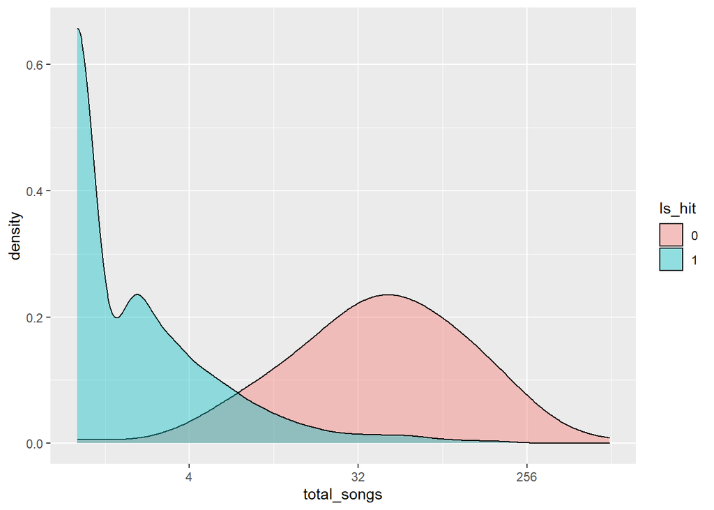

```r
#checking distribution of songs by genre and class
by_genre_key_mode %>%
ggplot(., aes(x=total_songs, group=Is_hit, fill=Is_hit)) +
  geom_density(adjust=1.5, alpha=.4) +
  scale_x_continuous(trans='log2')
```

- relationship between mode and key:

```r
#considering key and mode relationship
prop.table(table(training[,c("key","mode")]) ) *100
```

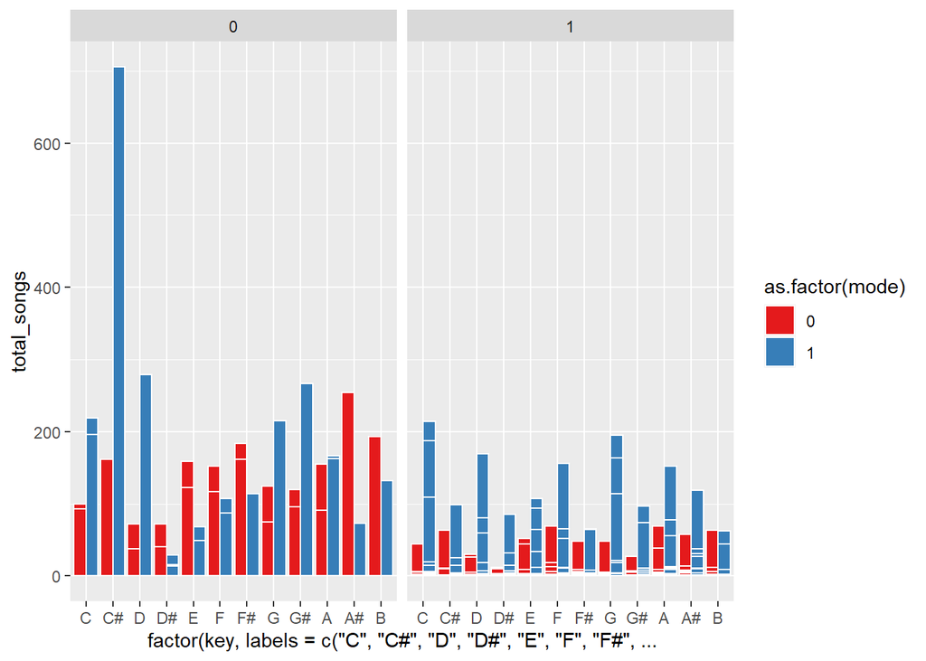

```r
#considering key and mode relationship
by_genre_key_mode %>%
ggplot(., aes(x = factor(key, labels =c("C","C#","D","D#","E","F","F#","G","G#","A","A#","B")), y = total_songs))+
  geom_bar(
    aes(fill = as.factor(mode) ), stat = "identity", color = "white",
    position = position_dodge(0.9)
  )+
  facet_wrap(~ Is_hit) +
  scale_fill_brewer(palette = "Set1")
```

- considering mode by itself as potential predictor:

Understanding whether there is dependency between the class variable (“Is_hit”) and Mode:

```r
prop.table(table(training[,c("Is_hit","mode")]), margin = 2 ) *100
```

```
##       mode
## Is_hit        0        1
##    No  60.31438 44.48220
##    Yes 39.68562 55.51780
```